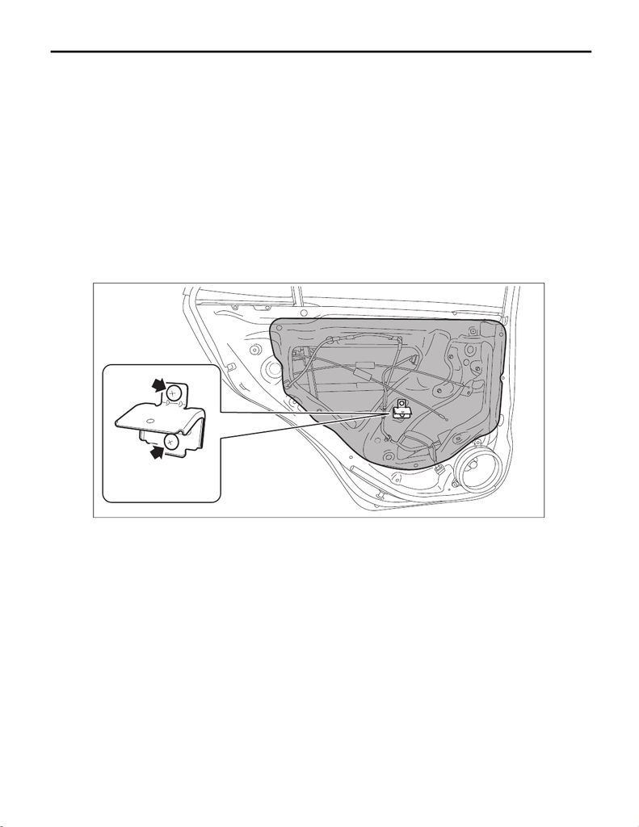

Rear Sealing Cover

EXTERIOR BODY PANELS

7. Rear Sealing Cover

A: REMOVAL

1) Disconnect the ground cable from battery. <Ref. to NT-5, BATTERY, NOTE, Note.>

NOTE:

For models other than STI model, disconnect the ground terminal from battery sensor.

2) Remove the trim panel - rear door. <Ref. to EI-57, REAR DOOR, REMOVAL, Door Trim.>

3) Remove the sealing cover - rear door.

CAUTION:

• Carefully remove the butyl tape. Excessive force will easily break the cover.

• If the sealing cover - rear door gets broken, replace it with a new part.

(1) Remove the screw to remove the bracket - door trim rear.

(2) Disconnect connectors.

(3) Carefully remove the butyl tape to remove the sealing cover - rear door.

B: INSTALLATION

CAUTION:

• If the sealing cover - rear door gets broken, replace it with a new part.

• Apply a butyl tape evenly.

• Attach the sealing cover - rear door, keeping it from becoming wrinkled.

• If the butyl tape is applied unevenly, it will cause water leakage and soiling.

1) Install the sealing cover.

(1) Forcefully push the butyl tape portion to prevent any floating on surface.

(2) When replacing the sealing cover, use the butyl tape.

Butyl tape:

3M Butyl Rubber 8626 or equivalent

2) Install the trim panel - rear door. <Ref. to EI-58, INSTALLATION, Door Trim.>

3) Connect the battery ground terminal. <Ref. to NT-5, BATTERY, NOTE, Note.>

NOTE:

For models other than STI model, connect the ground terminal to battery sensor.

C: INSPECTION

If the sealing cover - rear door is broken, replace it with a new part.